# Zhang Quiz 1: Part 2

## Part 2: Coding in action

### Instructions

Please answer these questions in R using whatever syntax makes sense to you. Feel free to use the R help pages and/or notes from class.

**If you use Google or ChatGPT etc. to help you get to an answer, please note so on your answer**

Submit your answers as an html file. Name it “lastname_quiz1.html”. Two submission options:  
1. Email to mcnew@arizona.edu 2. Create a branch in your forked-and-cloned class repo. Add the html file to the student_contributions/ folder. Submit a pull request to Sabrina (extra credit).

```r
# load packages and data
library(ggplot2)
library(dslabs)
library(dplyr)
```

#### Load your data:

Load the *swallows.csv* into R, call it swallows. This data frame lists results of an experiment on tree swallows. Each row is a nest. Nests were put into one of two **treatments**: simulated predation (predator), or control (control). Along with treatment you have the following columns:  
**nest_fate** = whether the nest fledged any young or whether they all died  
**brood** = number of nestlings  
**n_fledged** = number of nestlings that fledged.

You also have a separate data frame called *brightness.csv* where each row lists the plumage brightness (a sexual signal) for the female at each nest. Load this one up too.

1. 1. ```r
      # Answer
       swallows<-read.csv("swallows.csv", header = TRUE)
       brightness<-read.csv("brightness.csv", header = TRUE)

      # Google? y/n
       #n
      ```

#### Wrangle your data

You realize that you want to add brightness information onto your main swallows data frame. Join these data frames using nest_id as your key variable. Describe how you would check to make sure this join worked as intended.

```r
#Answer
comb_data <- swallows %>%
  left_join(brightness, by = "nestbox")
# Google? y/n
#n
```

Inspect your combined data frame. Do some sort of quick sanity check on each column to catch any obvious entry errors. Correct as necessary

```r
# Answer
str(comb_data)
```

```
'data.frame':   42 obs. of  5 variables:
 $ nestbox   : chr  "2_124" "2_22" "2_109" "2_8" ...
 $ treatment : chr  "Control" "Control" "Predation" "Control" ...
 $ brood     : int  6 5 5 5 6 3 4 5 5 5 ...
 $ n_fledged : int  2 5 2 3 6 2 4 5 1 4 ...
 $ brightness: num  58.4 57.7 NA 55.7 58.6 54.2 41.5 39.9 49.3 68 ...
```

```r
summary(comb_data)
```

```
   nestbox           treatment             brood         n_fledged
 Length:42          Length:42          Min.   :0.000   Min.   :0.000
 Class :character   Class :character   1st Qu.:4.000   1st Qu.:0.000
 Mode  :character   Mode  :character   Median :5.000   Median :2.000
                                       Mean   :4.381   Mean   :2.167
                                       3rd Qu.:5.750   3rd Qu.:4.000
                                       Max.   :7.000   Max.   :6.000

   brightness
 Min.   :33.9
 1st Qu.:47.1
 Median :53.3
 Mean   :51.2
 3rd Qu.:57.0
 Max.   :68.0
 NA's   :1
```

```r
colSums(is.na(comb_data))
```

```
   nestbox  treatment      brood  n_fledged brightness
         0          0          0          0          1
```

```r
comb_new <- comb_data %>%
  filter(!is.na(brightness))
# Google y/n
#y for NA values
```

Create a new column called prop_fledged that contains the proportion of nestlings that fledged from each nest.

```r
#Answer

comb_new2 <- comb_new %>%
  mutate(prop_fledged = ifelse(brood>0, n_fledged/brood, NA))

# Google? y/n
#n
```

#### Explore the data

What was the mean proportion of nestlings fledged in each treatment?

```r
# Answer
comb_new2 %>%
  group_by(treatment) %>%
  summarize(mean_fledged = mean(prop_fledged, na.rm = TRUE))
```

```
# A tibble: 2 × 2
  treatment mean_fledged
  <chr>            <dbl>
1 Control          0.706
2 Predation        0.332
```

```r
# Google? y/n
#y
```

Create a plot showing fledging success differences between treatments

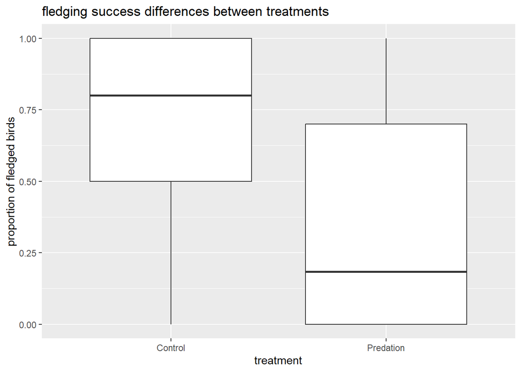

```r
#Answer
ggplot(comb_new2, aes(x = treatment, y = prop_fledged)) +
  geom_boxplot() +
  labs(x = "treatment", y = "proportion of fledged birds",
       title = "fledging success differences between treatments")
```

```r
# Google? y/n
#n
```

Is there any evidence that female brightness influenced fledging success? Create a plot to visually investigate this question.

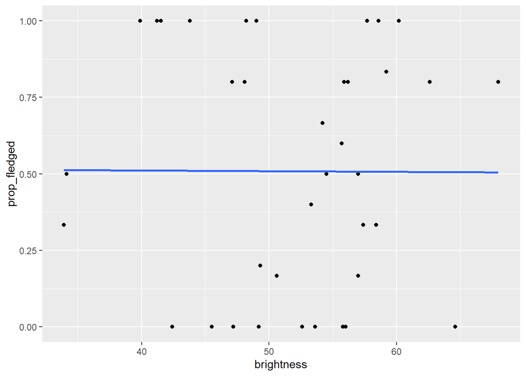

```r
#Answer
# Convert a column to numeric
comb_new2$brightness<- as.numeric(comb_new2$brightness)



ggplot(data.frame(comb_new2), aes(x = brightness, y = prop_fledged)) +
  geom_point() +
  geom_smooth(method = "lm", se = FALSE)
```

```r
# Google? y/n
#n
```